# House_price

完整的一次数据预测项目，使用的是ames房价预测数据集。首先查看数据

```r
str(data)
```

```
## 'data.frame':    2930 obs. of  83 variables:
##  $ PID               : int  526301100 526350040 526351010 526353030 527105010 527105030 527127150 527145080 527146030 527162130 ...
##  $ MS_SubClass       : chr  "One_Story_1946_and_Newer_All_Styles" "One_Story_1946_and_Newer_All_Styles" "One_Story_1946_and_Newer_All_Styles" "One_Story_1946_and_Newer_All_Styles" ...
##  $ MS_Zoning         : chr  "Residential_Low_Density" "Residential_High_Density" "Residential_Low_Density" "Residential_Low_Density" ...
##  $ Lot_Frontage      : int  141 80 81 93 74 78 41 43 39 60 ...
##  $ Lot_Area          : int  31770 11622 14267 11160 13830 9978 4920 5005 5389 7500 ...
##  $ Street            : chr  "Pave" "Pave" "Pave" "Pave" ...
##  $ Alley             : chr  "No_Alley_Access" "No_Alley_Access" "No_Alley_Access" "No_Alley_Access" ...
##  $ Lot_Shape         : chr  "Slightly_Irregular" "Regular" "Slightly_Irregular" "Regular" ...
##  $ Land_Contour      : chr  "Lvl" "Lvl" "Lvl" "Lvl" ...
##  $ Utilities         : chr  "AllPub" "AllPub" "AllPub" "AllPub" ...
##  $ Lot_Config        : chr  "Corner" "Inside" "Corner" "Corner" ...
##  $ Land_Slope        : chr  "Gtl" "Gtl" "Gtl" "Gtl" ...
##  $ Neighborhood      : chr  "North_Ames" "North_Ames" "North_Ames" "North_Ames" ...
##  $ Condition_1       : chr  "Norm" "Feedr" "Norm" "Norm" ...
```

[output cut: 69 more lines]

数据集包含2930个observations与83个变量，变量包含数值变量与非数值变量，我们需要在数据预处理时对非数值变量进行处理。

```r
# Error_vec_lasso=rep(0,10)
# Error_vec_xgboost=rep(0,10)

#for (k in 1:10){

k=2

train <- data[-testIDs[,k], ]
test <- data[testIDs[,k], ]
test.y <- test[, c(1, 83)]
test <- test[, -83]
write.csv(train,"train.csv",row.names=FALSE)
write.csv(test, "test.csv",row.names=FALSE)
write.csv(test.y,"test_y.csv",row.names=FALSE)

train <- read.csv("train.csv")
test <- read.csv("test.csv")
```

首先是划分数据集，testIDs中包含打乱的测试数据的序号，用于10-fold检验，在这里将k设置为2，也就是抽取第二组测试数据序号，一共有十组。

```r
train$Garage_Yr_Blt[is.na(train$Garage_Yr_Blt)] = 0


train<- subset(train,select=-c(Street, Utilities,Condition_2, Roof_Matl, Heating, Pool_QC, Misc_Feature, Low_Qual_Fin_SF, Pool_Area, Longitude,Latitude))

test$Garage_Yr_Blt[is.na(test$Garage_Yr_Blt)] = 0

test <- subset(test, select = -c(Street, Utilities,Condition_2, Roof_Matl, Heating, Pool_QC, Misc_Feature, Low_Qual_Fin_SF, Pool_Area, Longitude,Latitude))

test<- test[,-1]
```

然后我是删除了一些变量，这是因为在直观上，我认为这些变量是与预测变量没有任何关系的，比如说街道，维度，经度以及一些可翻修的房屋变量。

```r
train<- train[,-1]
train.y=train[,dim(train)[2]]
train.x=train[,-dim(train)[2]]
n_train=dim(train.x)[1]


train.x=rbind(train.x,test)   ## rbind
categorical.vars <- colnames(train.x)[
  which(sapply(train.x,
               function(x) mode(x)=="character"))]
train.matrix <- train.x[, !colnames(train.x) %in% categorical.vars,
                      drop=FALSE]
n.train <- nrow(train.matrix)
for(var in categorical.vars){
  mylevels <- sort(unique(train.x[, var]))
  m <- length(mylevels)
  m <- ifelse(m>2, m, 1)
  tmp.train <- matrix(0, n.train, m)
  col.names <- NULL
  for(j in 1:m){
    tmp.train[train.x[, var]==mylevels[j], j] <- 1
    col.names <- c(col.names, paste(var, '_', mylevels[j], sep=''))
  }
  colnames(tmp.train) <- col.names
  train.matrix <- cbind(train.matrix, tmp.train)
}

test=train.matrix[c((n_train+1):dim(train.matrix)[1]),]
train.x=train.matrix[c(1:n_train),]
```

然后就是将分类变量变为虚拟变量，也就是变为布尔类型的数据，这无疑会带来维度上的急剧增长，所以对于中大型数据集的虚拟变量的转换，数据降维是必要的。

```r
winsor.vars <- c("Lot_Frontage", "Lot_Area", "Mas_Vnr_Area", "BsmtFin_SF_2", "Bsmt_Unf_SF", "Total_Bsmt_SF", "Second_Flr_SF", 'First_Flr_SF', "Gr_Liv_Area", "Garage_Area", "Wood_Deck_SF", "Open_Porch_SF",  "Screen_Porch", "Misc_Val")

quan.value <- 0.95

for(var in winsor.vars){
  tmp <- train.x[, var]
  myquan <- quantile(tmp, probs = quan.value, na.rm = TRUE)
  tmp[tmp > myquan] <- myquan
  train.x[, var] <- tmp
}


for(var in winsor.vars){
  tmp <- test[, var]
  myquan <- quantile(tmp, probs = quan.value, na.rm = TRUE)
  tmp[tmp > myquan] <- myquan
  test[, var] <- tmp
}
```

下一步就是winsorize数据处理，这是处理离群值点的一种，也是降低过拟合的一种方法。Winsorization是应该将超出变量特定百分位范围的数值替换为其特定百分位数值的方法。

```r
#### scale the numeric variable
train.x$Year_Built=scale(train.x$Year_Built, center = TRUE, scale = FALSE)
train.x$Year_Remod_Add=scale(train.x$Year_Remod_Add, center = TRUE, scale = FALSE)
train.x$Garage_Yr_Blt=scale(train.x$Garage_Yr_Blt, center = TRUE, scale = FALSE)
train.x$Year_Sold=scale(train.x$Year_Sold, center = TRUE, scale = FALSE)
train.x$Year_Built=scale(train.x$Year_Built, center = TRUE, scale = FALSE)

test$Year_Built=scale(test$Year_Built, center = TRUE, scale = FALSE)
test$Year_Remod_Add=scale(test$Year_Remod_Add, center = TRUE, scale = FALSE)
test$Garage_Yr_Blt=scale(test$Garage_Yr_Blt, center = TRUE, scale = FALSE)
test$Year_Sold=scale(test$Year_Sold, center = TRUE, scale = FALSE)
test$Year_Built=scale(test$Year_Built, center = TRUE, scale = FALSE)
```

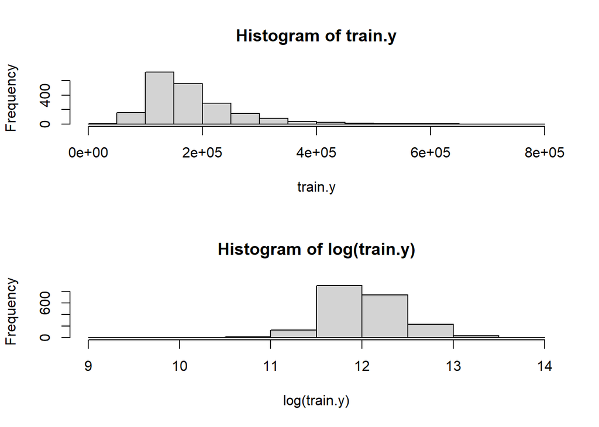

```r
par(mfrow=c(2,1))
hist(train.y)
hist(log(train.y))
```

```r
train.y=log(train.y)
```

上面是我认为做重要的，就是对预测变量取对数。我尝试过很多次，发现这个数据集中，对数化对lasso模型的帮助很大，能大幅提高预测精度，但对于XGBoost的用处几乎没有任何作用。

下面就是预测模型，用了两个预测模型，一个是通过Lasso进行变量筛选，再进行Ridge回归，一个是XGBoost模型

```r
set.seed(2021)
xgb.model <- xgboost(data = as.matrix(train.x),
                     label = train.y, max_depth = 6,
                     eta = 0.05, nrounds = 5000,
                     subsample = 0.5,
                     verbose = FALSE)

cv.out <- cv.glmnet(as.matrix(train.x[, xgb.model$feature_names]), train.y, alpha = 1)
sel.vars <- predict(cv.out, type="nonzero",
                    s = cv.out$lambda.1se)[,1]
cv.out <- cv.glmnet(as.matrix(train.x[, sel.vars]),
                    train.y, alpha = 0)


test.y <- read.csv("test_y.csv")
test.y=test.y[,2]


Ytest.pred <-predict(cv.out, s = cv.out$lambda.min, newx = as.matrix(test[, sel.vars]))

Ytest.pred=exp(Ytest.pred)
Error_vec_lasso=sqrt(mean((log(test.y) - log(Ytest.pred))^2))

xgb.pred = predict(xgb.model, newdata = as.matrix(test[,xgb.model$feature_names]))

xgb.pred=exp(xgb.pred)
Error_vec_xgboost=sqrt(mean((log(test.y) - log(xgb.pred))^2))

#}

Error_vec_lasso
```

```
## [1] 0.120437
```

```r
Error_vec_xgboost
```

```
## [1] 0.1194583
```

得到了两个结果，都在0.125以下，比较下来结果比较满意。写一个for循环就可以得到10组两个模型的结果，这里就不展示了